# Practical Machine Learning: Prediction Assignment

Mawriz

July 28, 2016

##### Project setup

```r
library(knitr)
library(caret)
library(rpart)
library(rpart.plot)
library(rattle)
library(ggplot2)
library(randomForest)
```

#### A) Background

Using devices such as Jawbone Up, Nike FuelBand, and Fitbit it is now possible to collect a large amount of data about personal activity relatively inexpensively. These type of devices are part of the quantified self movement - a group of enthusiasts who take measurements about themselves regularly to improve their health, to find patterns in their behavior, or because they are tech geeks. One thing that people regularly do is quantify how much of a particular activity they do, but they rarely quantify how well they do it. In this project, your goal will be to use data from accelerometers on the belt, forearm, arm, and dumbell of 6 participants. They were asked to perform barbell lifts correctly and incorrectly in 5 different ways. More information is available from the website here: [http://groupware.les.inf.puc-rio.br/har (see the section on the Weight Lifting Exercise Dataset)].

This project is aimed at: - Predicting the manner in which the exercise was done, which is the “classe” variable. - Creating a report describing how the model was built and how cross validation was used. - Use the prediction model to predict 20 different test cases.

#### B) Data loading and manipulating

```r
set.seed(1)
trainData <- read.csv("pml-training.csv")
train <- createDataPartition(trainData $classe, p = 0.8, list = FALSE)
trainX <- trainData [train,]
testX <- trainData [-train,]
testData <- read.csv("pml-testing.csv")
dim(trainData)
```

```
## [1] 19622   160
```

```r
# remove near zero variance predictors
set.seed(1)
nzv <- nearZeroVar(trainX[, names(trainX) != "classe"])
trainX_filtered <- trainX[, -nzv]
testX_filtered <- testX[, -nzv]

dim(trainX_filtered)
```

```
## [1] 15699   103
```

```r
dim(testX_filtered)
```

```
## [1] 3923  103
```

```r
#remove near all NA predictors. Predictors with mean NA > 0.7 will be left out
set.seed(1)
rmNa <- sapply(trainX_filtered[, names(trainX_filtered) != "classe"], function(x) mean(is.na(x))) > 0.7

trainX_clean <- trainX_filtered[, rmNa==FALSE]
testX_clean <- testX_filtered[, rmNa==FALSE]

dim(trainX_clean)
```

```
## [1] 15699    59
```

```r
dim(testX_clean)
```

```
## [1] 3923   59
```

```r
#remove first five variables. They are mere identification variables and won't be used in prediction.
set.seed(1)
str(trainX_clean[, 1:5])
```

```
## 'data.frame':    15699 obs. of  5 variables:
##  $ X                   : int  2 3 4 5 6 7 8 9 10 11 ...
##  $ user_name           : Factor w/ 6 levels "adelmo","carlitos",..: 2 2 2 2 2 2 2 2 2 2 ...
##  $ raw_timestamp_part_1: int  1323084231 1323084231 1323084232 1323084232 1323084232 1323084232 1323084232 1323084232 1323084232 1323084232 ...
##  $ raw_timestamp_part_2: int  808298 820366 120339 196328 304277 368296 440390 484323 484434 500302 ...
##  $ cvtd_timestamp      : Factor w/ 20 levels "02/12/2011 13:32",..: 9 9 9 9 9 9 9 9 9 9 ...
```

```r
trainX_clean  <- trainX_clean[,-(1:5) ]
testX_clean  <- testX_clean[,-(1:5) ]
dim(trainX_clean)
```

```
## [1] 15699    54
```

```r
dim(testX_clean)
```

```
## [1] 3923   54
```

```r
# check for colinear predictors and remove
set.seed(1)
corMatrix <- cor(trainX_clean[, names(trainX_clean) != "classe"])
highlyCor <- findCorrelation(corMatrix, cutoff = .80)

# predictors with correlation of less than |0.8| will be used
trainX_clean  <- trainX_clean[,-highlyCor ]
testX_clean  <- testX_clean[,-highlyCor ]
corTrain <- cor(trainX_clean[, names(trainX_clean) != "classe"])
summary(corTrain[upper.tri(corTrain)])
```

```
##      Min.   1st Qu.    Median      Mean   3rd Qu.      Max.
## -0.772700 -0.103100  0.009253  0.011690  0.108900  0.790900
```

```r
dim(trainX_clean)
```

```
## [1] 15699    41
```

```r
dim(testX_clean)
```

```
## [1] 3923   41
```

```r
names(trainX_clean)
```

```
##  [1] "num_window"           "yaw_belt"             "total_accel_belt"
##  [4] "gyros_belt_x"         "gyros_belt_y"         "gyros_belt_z"
##  [7] "magnet_belt_x"        "magnet_belt_y"        "magnet_belt_z"
## [10] "roll_arm"             "pitch_arm"            "yaw_arm"
## [13] "total_accel_arm"      "gyros_arm_y"          "gyros_arm_z"
## [16] "accel_arm_y"          "accel_arm_z"          "magnet_arm_x"
## [19] "magnet_arm_z"         "roll_dumbbell"        "pitch_dumbbell"
## [22] "yaw_dumbbell"         "total_accel_dumbbell" "gyros_dumbbell_y"
## [25] "accel_dumbbell_y"     "magnet_dumbbell_x"    "magnet_dumbbell_y"
## [28] "magnet_dumbbell_z"    "roll_forearm"         "pitch_forearm"
## [31] "yaw_forearm"          "total_accel_forearm"  "gyros_forearm_x"
## [34] "gyros_forearm_z"      "accel_forearm_x"      "accel_forearm_y"
## [37] "accel_forearm_z"      "magnet_forearm_x"     "magnet_forearm_y"
## [40] "magnet_forearm_z"     "classe"
```

#### C) Model Building

Four models will be analysed and the one with the highest accuracy used to predict the test dataset. In this exercise repeated cross validation, 10-fold cross validation and 3 repeats will be used to give a more robust estimate.

**1. Rpart Model**

```r
set.seed(1)
control <- trainControl(method = "repeatedcv",
                       number = 10, repeats = 3,
                       verboseIter = FALSE,
                       allowParallel = TRUE )

metric <- "Accuracy"

fit.rpart <- train(classe ~ .,data = trainX_clean,
                  method = "rpart",
                  preProc = c("scale", "center"),
                  metric = metric,
                  trControl = control)

rpartPred <- predict(fit.rpart, testX_clean)
dconfMatrix <- confusionMatrix(rpartPred, testX_clean$classe)
dconfMatrix
```

```
## Confusion Matrix and Statistics
##
##           Reference
## Prediction   A   B   C   D   E
##          A 936 119  12  66  60
##          B  21 238  19 114 137
##          C 159 399 653 411 290
##          D   0   0   0   0   0
##          E   0   3   0  52 234
##
## Overall Statistics
##
##                Accuracy : 0.5254
##                  95% CI : (0.5096, 0.5411)
##     No Information Rate : 0.2845
##     P-Value [Acc > NIR] : < 2.2e-16
##
##                   Kappa : 0.3983
##  Mcnemar's Test P-Value : < 2.2e-16
##
## Statistics by Class:
##
##                      Class: A Class: B Class: C Class: D Class: E
## Sensitivity            0.8387  0.31357   0.9547   0.0000  0.32455
## Specificity            0.9084  0.90803   0.6113   1.0000  0.98282
## Pos Pred Value         0.7846  0.44991   0.3415      NaN  0.80969
## Neg Pred Value         0.9341  0.84649   0.9846   0.8361  0.86599
## Prevalence             0.2845  0.19347   0.1744   0.1639  0.18379
## Detection Rate         0.2386  0.06067   0.1665   0.0000  0.05965
## Detection Prevalence   0.3041  0.13485   0.4874   0.0000  0.07367
## Balanced Accuracy      0.8736  0.61080   0.7830   0.5000  0.65369
```

**2. Random Forest Model**

```r
set.seed(1)
fit.rf <- train(classe ~ .,data = trainX_clean,
                  method = "rf",
                  preProc = c("scale", "center"),
                  trControl = control)
```

```r
# Prdict on test data
randPred <- predict(fit.rf, testX_clean)
rfMatrix <- confusionMatrix(data = randPred, testX_clean$classe)
rfMatrix
```

```
## Confusion Matrix and Statistics
##
##           Reference
## Prediction    A    B    C    D    E
##          A 1116    2    0    0    0
##          B    0  756    2    0    0
##          C    0    1  681    5    0
##          D    0    0    1  638    0
##          E    0    0    0    0  721
##
## Overall Statistics
##
##                Accuracy : 0.9972
##                  95% CI : (0.995, 0.9986)
##     No Information Rate : 0.2845
##     P-Value [Acc > NIR] : < 2.2e-16
##
##                   Kappa : 0.9965
##  Mcnemar's Test P-Value : NA
##
## Statistics by Class:
##
##                      Class: A Class: B Class: C Class: D Class: E
## Sensitivity            1.0000   0.9960   0.9956   0.9922   1.0000
## Specificity            0.9993   0.9994   0.9981   0.9997   1.0000
## Pos Pred Value         0.9982   0.9974   0.9913   0.9984   1.0000
## Neg Pred Value         1.0000   0.9991   0.9991   0.9985   1.0000
## Prevalence             0.2845   0.1935   0.1744   0.1639   0.1838
## Detection Rate         0.2845   0.1927   0.1736   0.1626   0.1838
## Detection Prevalence   0.2850   0.1932   0.1751   0.1629   0.1838
## Balanced Accuracy      0.9996   0.9977   0.9969   0.9960   1.0000
```

**3. Stochastic Gradient Boosting (Generalized Boosted Modeling)**

```r
fit.gbm <- train(classe ~ .,data = trainX_clean,
                 method = "gbm",
                 metric = metric,
                 trControl = control)
```

```r
# Prdict on test data
gbmPred <- predict(fit.gbm, testX_clean)
gbmMatrix <- confusionMatrix(gbmPred, testX_clean$classe)
gbmMatrix
```

```
## Confusion Matrix and Statistics
##
##           Reference
## Prediction    A    B    C    D    E
##          A 1114    3    0    0    0
##          B    1  754    7    0    1
##          C    0    2  675    4    2
##          D    1    0    2  638    2
##          E    0    0    0    1  716
##
## Overall Statistics
##
##                Accuracy : 0.9934
##                  95% CI : (0.9903, 0.9957)
##     No Information Rate : 0.2845
##     P-Value [Acc > NIR] : < 2.2e-16
##
##                   Kappa : 0.9916
##  Mcnemar's Test P-Value : NA
##
## Statistics by Class:
##
##                      Class: A Class: B Class: C Class: D Class: E
## Sensitivity            0.9982   0.9934   0.9868   0.9922   0.9931
## Specificity            0.9989   0.9972   0.9975   0.9985   0.9997
## Pos Pred Value         0.9973   0.9882   0.9883   0.9922   0.9986
## Neg Pred Value         0.9993   0.9984   0.9972   0.9985   0.9984
## Prevalence             0.2845   0.1935   0.1744   0.1639   0.1838
## Detection Rate         0.2840   0.1922   0.1721   0.1626   0.1825
## Detection Prevalence   0.2847   0.1945   0.1741   0.1639   0.1828
## Balanced Accuracy      0.9986   0.9953   0.9922   0.9953   0.9964
```

[output not shown]

[output not shown]

### E). Model Selection

We can now evaluate and compare them.

```r
results <- resamples(list(Rpart = fit.rpart,
                    rf = fit.rf,
                    gbm = fit.gbm,
                    lda = fit.lda))
#Table comparison
summary(results)
```

```
##
## Call:
## summary.resamples(object = results)
##
## Models: Rpart, rf, gbm, lda
## Number of resamples: 30
##
## Accuracy
##         Min. 1st Qu. Median   Mean 3rd Qu.   Max. NA's
## Rpart 0.5025  0.5280 0.5413 0.5394  0.5541 0.5631    0
## rf    0.9955  0.9968 0.9975 0.9975  0.9986 0.9994    0
## gbm   0.9854  0.9892 0.9898 0.9900  0.9916 0.9949    0
## lda   0.6382  0.6461 0.6543 0.6546  0.6611 0.6726    0
##
## Kappa
##         Min. 1st Qu. Median   Mean 3rd Qu.   Max. NA's
## Rpart 0.3708  0.4032 0.4189 0.4170  0.4363 0.4478    0
## rf    0.9944  0.9960 0.9968 0.9969  0.9982 0.9992    0
## gbm   0.9815  0.9863 0.9871 0.9874  0.9893 0.9936    0
## lda   0.5432  0.5517 0.5629 0.5630  0.5714 0.5854    0
```

From these results, it looks like ensembles of trees models (i.e. `rf` and `gbm`) do well on this problem. I would predict the test results from the random forest model.

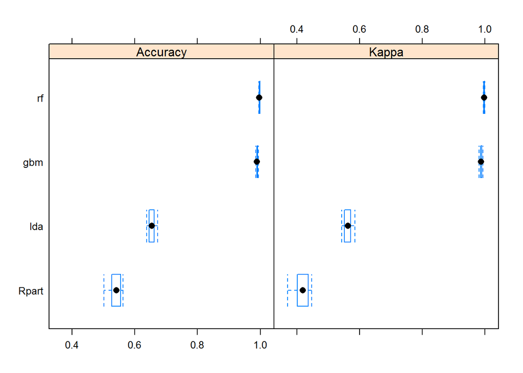

```r
# boxplot comparison
bwplot(results)
```

#### E) Apply Selected Model to Test Data

```r
final <- predict(fit.rf,  newdata = testData)
final
```

```
##  [1] B A B A A E D B A A B C B A E E A B B B
## Levels: A B C D E
```